# Predicting Exercise Class:

### Practical Machine Learning Course Project

**kwalker**  
**April 23, 2015**

## Project Goals

The goal of your project is to predict the manner in which they did the exercise. This is the “classe” variable in the training set. You may use any of the other variables to predict with. You should create a report describing how you built your model, how you used cross validation, what you think the expected out of sample error is, and why you made the choices you did. You will also use your prediction model to predict 20 different test cases.

1. Your submission should consist of a link to a Github repo with your R markdown and compiled HTML file describing your analysis. Please constrain the text of the writeup to < 2000 words and the number of figures to be less than 5. It will make it easier for the graders if you submit a repo with a gh-pages branch so the HTML page can be viewed online (and you always want to make it easy on graders :-).
2. You should also apply your machine learning algorithm to the 20 test cases available in the test data above. Please submit your predictions in appropriate format to the programming assignment for automated grading. See the programming assignment for additional details.

# Data

The training data for this project are available here:  
https://d396qusza40orc.cloudfront.net/predmachlearn/pml-training.csv

The test data are available here:  
https://d396qusza40orc.cloudfront.net/predmachlearn/pml-testing.csv

The data for this project comes from this original source: http://groupware.les.inf.puc-rio.br/har.

# Report

**Cross Validation:** I split the training data (pml-training.csv) into 75% train and 25% test data in order to fit a model that will ultimately be used to predict the testing data (pml-testing.csv). Training the model on 75% of the training data and testing against a reserved 25% will help avoid overfitting and ensure that the model does indeed predict well on new data in addition to helping us predict the out of sample error.

# Code Setup and Cleaning/Transformations

```r
library("knitr")
library("caret")
library("rattle")
library("randomForest")
set.seed(12345)
opts_chunk$set(cache=TRUE, message=FALSE, warning=FALSE, fig.height=5, fig.width=5)
```

### Load in the data

```r
setwd("/Users/kwalker/git_projects/PredMod_CourseProject/")
raw_test <- read.csv("pml-testing.csv", na.strings=c("NA", "#DIV/0", ""), stringsAsFactors=FALSE)
raw_train <- read.csv("pml-training.csv", na.strings=c("NA", "#DIV/0", ""), stringsAsFactors=FALSE)
```

### Clean the data

1. Remove variables that are mostly NAs
2. Remove first 6 descriptors (user_name, etc.)
3. Change format to numeric for all but classe
4. Remove collinear variables

```r
clean <- raw_train

# transform: remove variables that are mostly NA
clean.cut <- clean[,colSums(is.na(clean)) == 0]

# transform: remove first 6 descriptors
clean.cut <- clean.cut[ ,-c(1:6)]

# make numeric
for (i in 1:53 ) clean.cut[,i] <- as.numeric(clean.cut[,i])

# remove collinear variables
co <- cor(clean.cut[ ,1:53], use="pairwise.complete.obs")
diag(co) <- 0
pairs <- NULL
for ( i in 1:length(co[,1]) ) {
     for ( x in 1:length(co[1,])) {
          if (!is.na(co[x,i]) & co[x,i] > .9) {
               z <- i + 1
               m <- x + 1
               rname <- row.names(co[i:z,])[1]
               cname <- colnames(co[,x:m])[1]
               pairs <- rbind(pairs, c(rname, cname, co[x,i]))
          }
     }
}
pairs <- data.frame(pairs, stringsAsFactors=FALSE)
pairs <- pairs[order(-as.numeric(pairs$X3)),]
print(pairs)
```

```
##                 X1               X2                X3
## 1        roll_belt total_accel_belt 0.980924143698649
## 3 total_accel_belt        roll_belt 0.980924143698649
## 7 gyros_dumbbell_z  gyros_forearm_z 0.933042179694563
## 8  gyros_forearm_z gyros_dumbbell_z 0.933042179694563
## 4 total_accel_belt     accel_belt_y 0.927806920706301
## 6     accel_belt_y total_accel_belt 0.927806920706301
## 2        roll_belt     accel_belt_y 0.924898265903546
## 5     accel_belt_y        roll_belt 0.924898265903546
```

```r
collinears <- c("total_accel_belt", "gyros_dumbell_z", "accel_belt_y")
clean.cut <- clean.cut[ , !(colnames(clean.cut) %in% collinears)]
```

Perform the same transformations on test.

```r
cleanTest <- raw_test
# remove first six descriptors
cleanTest <- cleanTest[ ,-c(1:6)]

# make numeric
for (i in c(1:153) ) cleanTest[,i] <- as.numeric(cleanTest[,i])

# remove variables that are mostly NAs
cleanTest <- cleanTest[ ,colSums(is.na(cleanTest)) == 0]

# remove collinear variables
cleanTest <- cleanTest[ , !(colnames(cleanTest) %in% collinears)]
```

### Partition the Dataset for Cross Validation

Split the train data into 75% training and 25% testing.

```r
inTrain <- createDataPartition(y=clean.cut$classe, p=.75, list=FALSE)
training <- clean.cut[inTrain, ]
testing <- clean.cut[-inTrain, ]
```

# Model Fitting

### Trees/rpart

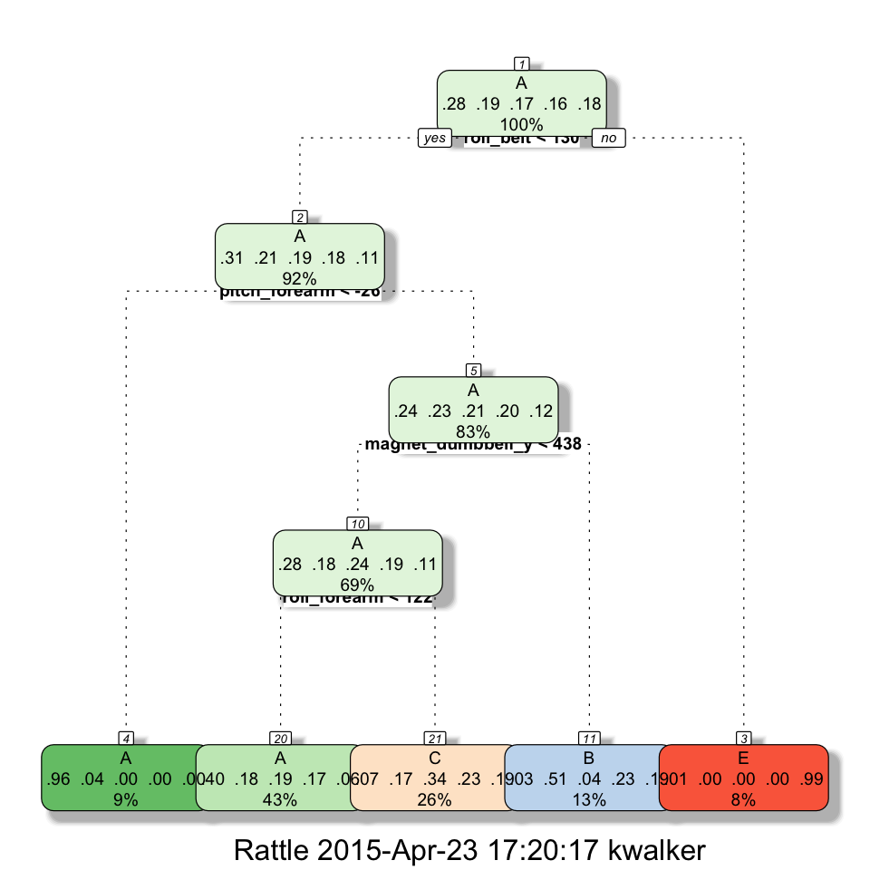

```r
# fit model
mod1 <- train(as.factor(classe)~., method="rpart", data=training)
fancyRpartPlot(mod1$finalModel, cex=.6)
```

Cross validate to check accuracy:

```r
# cross validate
mod1Predict <- predict(mod1, testing)
confusionMatrix(testing$classe, mod1Predict)
```

```
## Confusion Matrix and Statistics
##
##           Reference
## Prediction    A    B    C    D    E
##          A 1261   21  110    0    3
##          B  423  298  228    0    0
##          C  399   31  425    0    0
##          D  359  131  314    0    0
##          E  145  126  236    0  394
##
## Overall Statistics
##
##                Accuracy : 0.4849
##                  95% CI : (0.4708, 0.499)
##     No Information Rate : 0.5275
##     P-Value [Acc > NIR] : 1
##
##                   Kappa : 0.3262
##  Mcnemar's Test P-Value : NA
##
## Statistics by Class:
##
##                      Class: A Class: B Class: C Class: D Class: E
## Sensitivity            0.4874  0.49094  0.32369       NA  0.99244
## Specificity            0.9422  0.84850  0.88026   0.8361  0.88751
## Pos Pred Value         0.9039  0.31401  0.49708       NA  0.43729
## Neg Pred Value         0.6221  0.92187  0.78069       NA  0.99925
## Prevalence             0.5275  0.12378  0.26774   0.0000  0.08095
## Detection Rate         0.2571  0.06077  0.08666   0.0000  0.08034
## Detection Prevalence   0.2845  0.19352  0.17435   0.1639  0.18373
## Balanced Accuracy      0.7148  0.66972  0.60197       NA  0.93998
```

### Random Forest

```r
# fit model
mod2 <- randomForest(as.factor(classe)~., data=training)
```

Cross validate to check accuracy:

```r
# cross validate
mod2Predict <- predict(mod2, testing)
confusionMatrix(testing$classe, mod2Predict)
```

```
## Confusion Matrix and Statistics
##
##           Reference
## Prediction    A    B    C    D    E
##          A 1395    0    0    0    0
##          B    0  948    1    0    0
##          C    0    5  849    1    0
##          D    0    0    7  797    0
##          E    0    0    0    0  901
##
## Overall Statistics
##
##                Accuracy : 0.9971
##                  95% CI : (0.9952, 0.9984)
##     No Information Rate : 0.2845
##     P-Value [Acc > NIR] : < 2.2e-16
##
##                   Kappa : 0.9964
##  Mcnemar's Test P-Value : NA
##
## Statistics by Class:
##
##                      Class: A Class: B Class: C Class: D Class: E
## Sensitivity            1.0000   0.9948   0.9907   0.9987   1.0000
## Specificity            1.0000   0.9997   0.9985   0.9983   1.0000
## Pos Pred Value         1.0000   0.9989   0.9930   0.9913   1.0000
## Neg Pred Value         1.0000   0.9987   0.9980   0.9998   1.0000
## Prevalence             0.2845   0.1943   0.1748   0.1627   0.1837
## Detection Rate         0.2845   0.1933   0.1731   0.1625   0.1837
## Detection Prevalence   0.2845   0.1935   0.1743   0.1639   0.1837
## Balanced Accuracy      1.0000   0.9973   0.9946   0.9985   1.0000
```

# Submit

Generate test predictions.

```r
predictions <- predict(mod2, cleanTest)
```

Generate files to submit for grading.

```r
pml_write_files = function(x){
  n = length(x)
  for(i in 1:n){
    filename = paste0("problem_id_",i,".txt")
    write.table(x[i],file=filename,quote=FALSE,row.names=FALSE,col.names=FALSE)
  }
}

pml_write_files(predictions)
```